# Predicting GDP from Number of McDonalds’

# Can we use the number of McDonals’ in a country to predict its GDP?

```r
library(tidyverse)
library(ggplot2)
library(stringr)
library(rgdal)
```

First we are going to read in the data.

```r
# Scraped from wikipedia
md_data <- read.csv("McDonalds.csv")[-1]

# From https://www.kaggle.com/fernandol/countries-of-the-world
countries_data <- read.csv("countries of the world.csv")
```

Some rearanging must be done to line up the datasets.

```r
countries_data <- countries_data %>%
  mutate(Country = str_trim(Country))
Name <- as.character(countries_data$Country[!(countries_data$Country %in% md_data$Name)])
num_new <- length(Name)
First_opened <- rep(NA, num_new)
First_location <- rep(NA, num_new)
Count <- rep(0, num_new)
Source <- rep(NA, num_new)
People_per_md <- rep(NA, num_new)
Notes <- rep(NA, num_new)

more_countries <- data.frame(Name,First_opened, First_location, Count, Source, People_per_md, Notes)
md_data <- rbind(md_data, more_countries)
md_data <- md_data[md_data$Name %in% countries_data$Country,]

countries_data$Country <- countries_data$Country %>%
  str_replace("Viet Nam", "Vietnam") %>%
  str_replace("Trinidad and Tobago", "Trinidad & Tobago") %>%
  str_replace("South Korea", "Korea, South")

countries_data <- countries_data %>%
  mutate(Name = Country)

countries_data$md_count <- merge(x=countries_data, y=md_data, by= "Name", all.x = TRUE)$Count
countries_data$GDP <- countries_data$Population*(countries_data$GDP....per.capita./1000000)
```

The datasets were very mismatched. Sorry for the wall of code.

Let’s plot a density of McDonald’s count and GDP to get an idea of what we are dealing with.

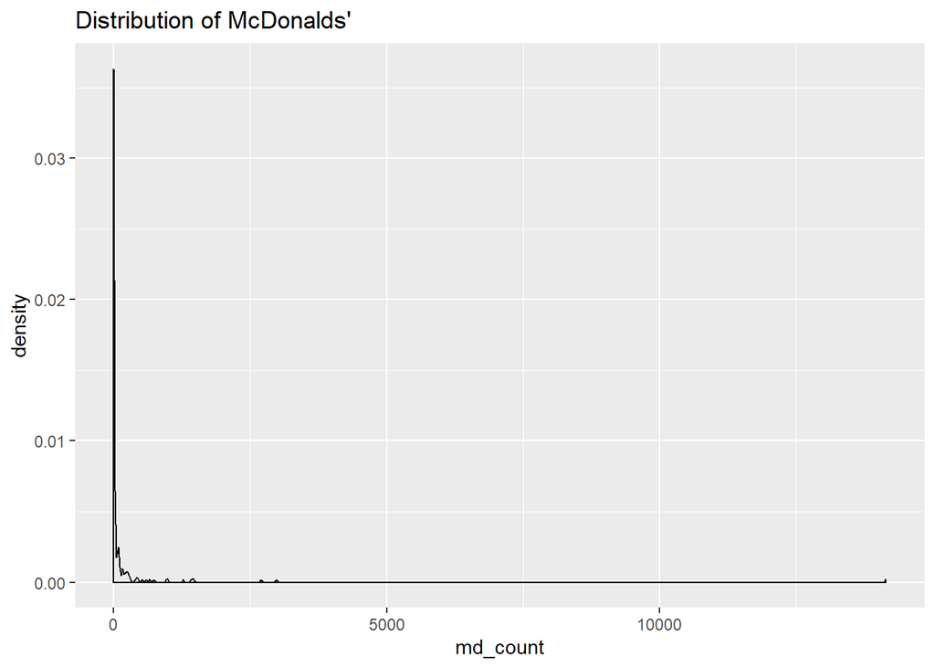

```r
# md count
countries_data %>%
  ggplot(aes(md_count)) +
  ggtitle("Distribution of McDonalds'")+
  geom_density()
```

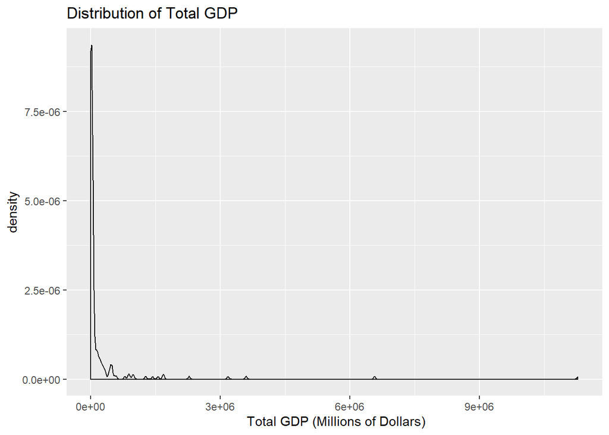

```r
# gdp
countries_data %>%
  ggplot(aes(GDP)) +
  ggtitle("Distribution of Total GDP")+
  xlab(" Total GDP (Millions of Dollars)") +
  geom_density()
```

Both of these plots are very skewed. Luckily they seem skewed in a similar matter. This gives us hope for a not-terrible prediction model.

Finally its time to construct a model.

```r
# Predict total GDP from the number of McDonalds'
my_model <- countries_data %>%
  lm(GDP ~ md_count, data=.)
summary(my_model)
```

```
##
## Call:
## lm(formula = GDP ~ md_count, data = .)
##
## Residuals:
##      Min       1Q   Median       3Q      Max
## -1171963   -89206   -81101   -47854  4120481
##
## Coefficients:
##             Estimate Std. Error t value Pr(>|t|)
## (Intercept) 89596.85   26828.78    3.34 0.000983 ***
## md_count      874.00      26.64   32.81  < 2e-16 ***
## ---
## Signif. codes:  0 '***' 0.001 '**' 0.01 '*' 0.05 '.' 0.1 ' ' 1
##
## Residual standard error: 397900 on 224 degrees of freedom
##   (1 observation deleted due to missingness)
## Multiple R-squared:  0.8277, Adjusted R-squared:  0.827
## F-statistic:  1076 on 1 and 224 DF,  p-value: < 2.2e-16
```

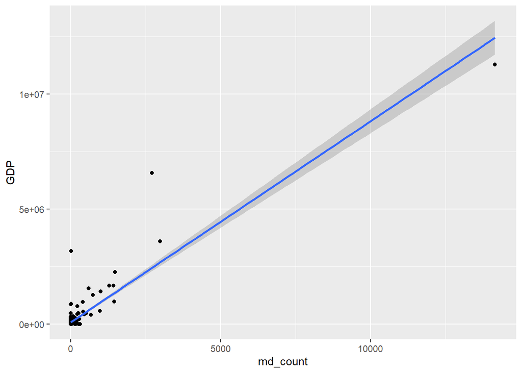

```r
countries_data %>%
  ggplot(aes(x = md_count, y = GDP)) +
  geom_point() +
  stat_smooth(method = "lm")
```

Overall, the GDP is fairly well described by McDonald’s count. The single point with nearly 15,000 McDonalds’ is of course the United States. Lucky for us, it makes up for all those Big Macs with a very large total GDP.